# Coursework-20603681

HELEN

2023-12-05

##INTRODUCTION

This is a statistical analysis for an ornithologist of data collected on kittiwakes, a type of gull with two sub-species of kittiwake, black-legged and red-legged. The exploratory data analysis, statistical inferences, correlation, fitting linear models, check for dependence and drawing inference from multiple comparisons between the sub-species of the kittiwake.

#Question1

```r
data<-read.csv("Kittiwake_Observation_20603681.csv")
```

```r
Observation <-data
```

```r
Observation
```

```
##    dawn noon mid.afternoon dusk
## 1    98   67            81   89
## 2    95   76            92   92
## 3   104   65            72   95
## 4   100   76            87  122
## 5    87   69            75   99
## 6   108   94            81   94
## 7    88   55            72  105
## 8   129   91            84  136
## 9    82   69            91   91
## 10  118   76            78   97
## 11  117   74            75   92
## 12  115   70            77   81
## 13   98   70            77  100
## 14  100   67            66  101
## 15  104   53            60   79
## 16  100   58            74   77
## 17  118   65            71  105
## 18  108   49            60   97
## 19  100   58            86   95
## 20   93   67            74  107
## 21  127   97            82  119
## 22   88   62            69   68
## 23   94   65            81   87
## 24   94   64            88   83
## 25  120  100            83  128
## 26   90   65            64   79
## 27   86   78            69  117
## 28  101   73            76  106
```

```r
head(Observation)
```

```
##   dawn noon mid.afternoon dusk
## 1   98   67            81   89
## 2   95   76            92   92
## 3  104   65            72   95
## 4  100   76            87  122
## 5   87   69            75   99
## 6  108   94            81   94
```

```r
dim(Observation)
```

```
## [1] 28  4
```

# Exploring the observation data

Summary statistics:Measures of Central tendency and Variability

```r
df_obs = data.frame(Observation)
df_obs
```

```
##    dawn noon mid.afternoon dusk
## 1    98   67            81   89
## 2    95   76            92   92
## 3   104   65            72   95
## 4   100   76            87  122
## 5    87   69            75   99
## 6   108   94            81   94
## 7    88   55            72  105
## 8   129   91            84  136
## 9    82   69            91   91
## 10  118   76            78   97
## 11  117   74            75   92
## 12  115   70            77   81
## 13   98   70            77  100
## 14  100   67            66  101
## 15  104   53            60   79
## 16  100   58            74   77
## 17  118   65            71  105
## 18  108   49            60   97
## 19  100   58            86   95
## 20   93   67            74  107
## 21  127   97            82  119
## 22   88   62            69   68
## 23   94   65            81   87
## 24   94   64            88   83
## 25  120  100            83  128
## 26   90   65            64   79
## 27   86   78            69  117
## 28  101   73            76  106
```

```r
summary(Observation)
```

```
##       dawn             noon        mid.afternoon        dusk
##  Min.   : 82.00   Min.   : 49.00   Min.   :60.00   Min.   : 68.00
##  1st Qu.: 93.75   1st Qu.: 64.75   1st Qu.:71.75   1st Qu.: 88.50
##  Median :100.00   Median : 68.00   Median :76.50   Median : 96.00
##  Mean   :102.21   Mean   : 70.46   Mean   :76.61   Mean   : 97.89
##  3rd Qu.:109.75   3rd Qu.: 76.00   3rd Qu.:82.25   3rd Qu.:105.25
##  Max.   :129.00   Max.   :100.00   Max.   :92.00   Max.   :136.00
```

```r
round(sd(Observation$dawn),2)
```

```
## [1] 12.75
```

```r
round(sd(Observation$noon), 2)
```

```
## [1] 12.63
```

```r
round(sd(Observation$mid.afternoon),2)
```

```
## [1] 8.58
```

```r
round(sd(Observation$dusk),2)
```

```
## [1] 16
```

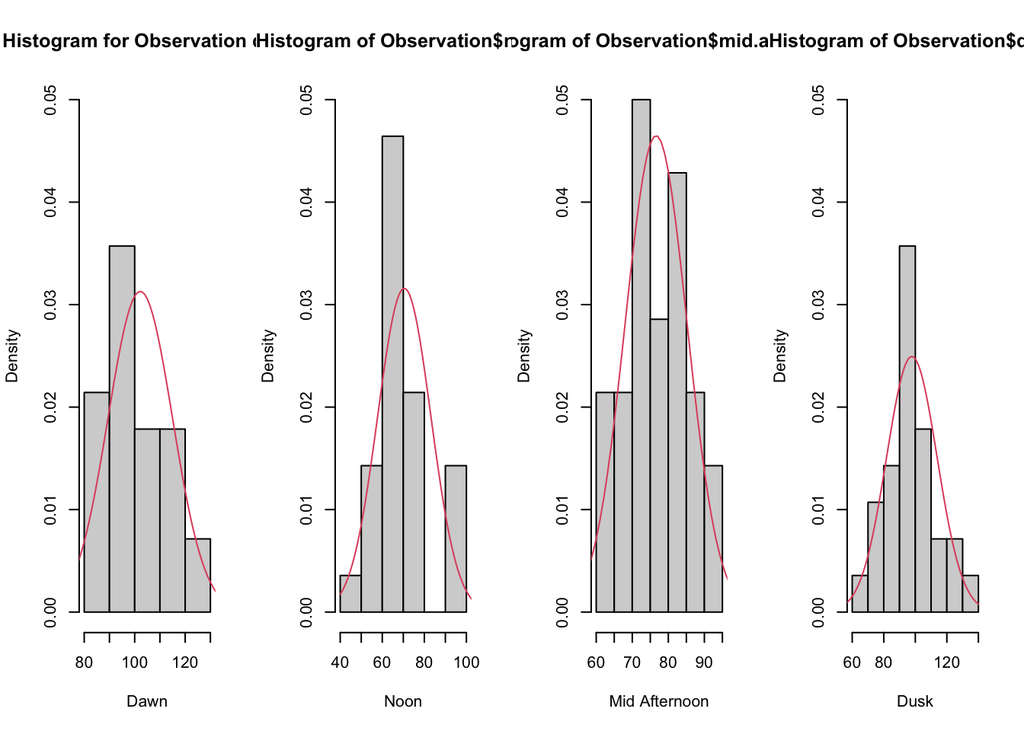

```r
par(mfrow=c(1,4))

hist(Observation$dawn, xlab= "Dawn", ylim=c(0,0.05), freq=FALSE, main="Histogram for Observation data" )
curve(dnorm(x, 102.21, 12.75), 40, 140, col=2,add=TRUE)

hist(Observation$noon, xlab= "Noon", ylim=c(0,0.05), freq=FALSE)
curve(dnorm(x, 70.46, 12.63),  40, 140, col=2,add=TRUE)

hist(Observation$mid.afternoon, ylim=c(0,0.05), xlab= "Mid Afternoon",freq=FALSE)
curve(dnorm(x, 76.61, 8.58), 40, 140, col=2,add=TRUE)

hist(Observation$dusk, ylim=c(0,0.05),  xlab= "Dusk", freq=FALSE)
curve(dnorm(x, 97.8, 16),  40, 140, col=2,add=TRUE)
```

Box plot for Observation data

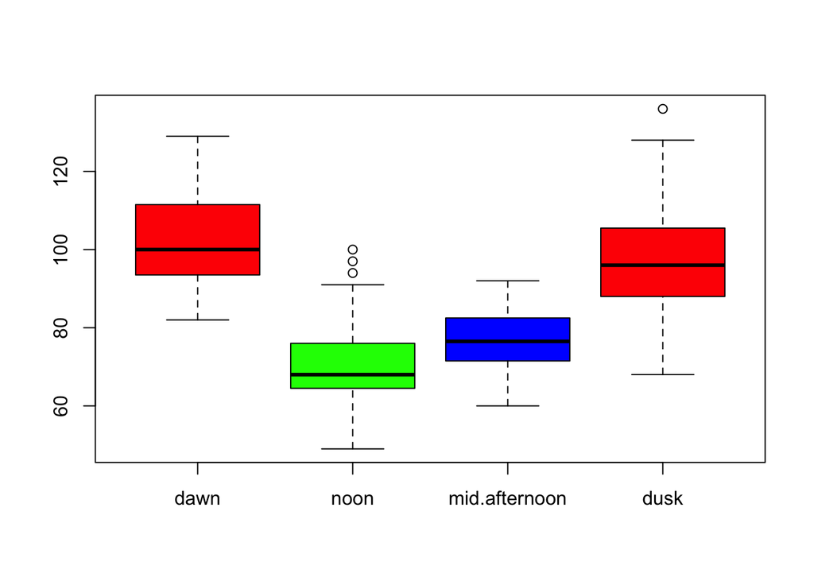

```r
boxplot(Observation, col = rainbow(ncol(trees)))
```

# Question 1B. To construct a 90% confidence interval for the mean number of kittiwakes observed at dusk.

Obtain the sample mean

```r
sampleMean <- round(mean(Observation$dusk),3)
sampleMean
```

```
## [1] 97.893
```

```r
sampleSD <- round(sd(Observation$dusk),2)
sampleSD
```

```
## [1] 16
```

```r
sampleVar = sampleSD**2
sampleVar
```

```
## [1] 256
```

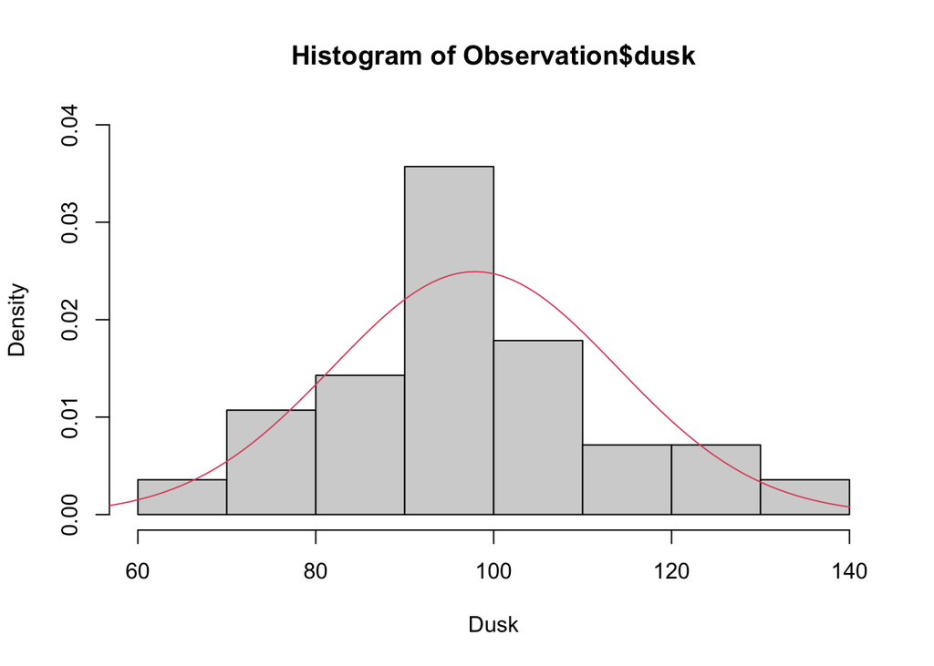

```r
hist(Observation$dusk, ylim=c(0,0.04),  xlab= "Dusk", freq=FALSE)
curve(dnorm(x, 97.893, 16),  40, 140, col=2,add=TRUE)
```

Calculating the confidence interval at the upper and lower.

```r
n <- 28
critical_value <- qt(0.95,n-1)
critical_value
```

```
## [1] 1.703288
```

```r
n <- 28  #sample size
confidence_level <- 0.90

lower<-sampleMean-qt(0.95, n-1)*sqrt(sampleVar/n) # calculate the lower limit of the confidence interval from the formula
lower
```

```
## [1] 92.74274
```

```r
upper<-sampleMean+qt(0.95, n-1)*sqrt(sampleVar/n) # calculate the upper limit of the confidence interval from the formula
upper
```

```
## [1] 103.0433
```

Using T-test to calculate the confidence interval

```r
t.test(Observation$dusk, conf.level = 0.9)$conf.int
```

```
## [1]  92.7416 103.0441
## attr(,"conf.level")
## [1] 0.9
```

```r
#install.packages("ggplot2")
```

```r
library(ggplot2)
```

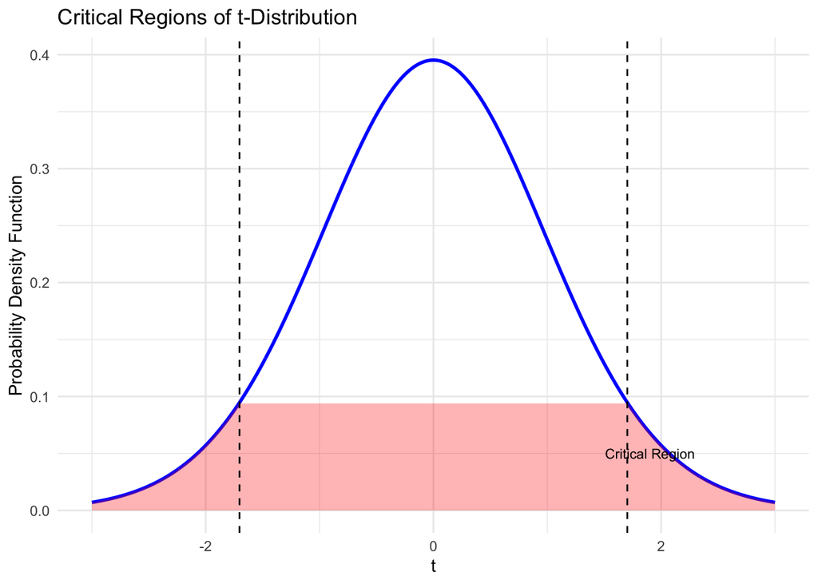

```r
df <- 27

critical_value <- 1.703288

#sequence of values for the x-axis
x_values <- seq(-3, 3, length.out = 1000)

# Creating a data frame with x values and corresponding probability density function (pdf) values
df <- data.frame(x = x_values, pdf = dt(x_values, df))

# Create a ggplot object with the t-distribution curve
plot <- ggplot(df, aes(x = x, y = pdf)) +geom_line(color = "blue", linewidth = 1) +theme_minimal() + labs(title = "Critical Regions of t-Distribution", x = "t",y = "Probability Density Function")

# Add shading to the critical regions
plot + geom_ribbon(data = subset(df, abs(x) > critical_value), aes(ymax = pdf, ymin = 0), fill = "red", alpha = 0.3) + geom_vline(xintercept = c(-critical_value, critical_value), linetype = "dashed", color = "black") + annotate("text", x = critical_value + 0.2, y = 0.05, label = "Critical Region", color = "black", size = 3)
```

```r
#Reference: https://stackoverflow.com/questions/53323782/plotting-the-area-under-the-curve-of-various-distributions-in-r
```

# Question 2

2. Does the Historical data support the ornithologist’s hypothesis that the decline in kittiwake numbers, over time, is independent of site? The ornithologist would like an estimate for the number of breeding pairs at site Site D in 2009.

Q2a.

```r
data<-read.csv("Kittiwake_Historical_20603681.csv")
```

```r
historical <- data
```

```r
head(historical)
```

```
##      X Site.A Site.B Site.C Site.D
## 1 2000     72     71     41     48
## 2 2004     68     69     31     41
## 3 2008     67     63     34     36
## 4 2012     57     57     30     29
## 5 2016     55     50     21     23
## 6 2020     43     46     18     23
```

```r
dim(historical)
```

```
## [1] 6 5
```

```r
colnames(historical)[1] <- "Year"
```

```r
historical
```

```
##   Year Site.A Site.B Site.C Site.D
## 1 2000     72     71     41     48
## 2 2004     68     69     31     41
## 3 2008     67     63     34     36
## 4 2012     57     57     30     29
## 5 2016     55     50     21     23
## 6 2020     43     46     18     23
```

```r
rownames(historical) <- historical$Year

historical <- historical[,-1]
```

```r
observed <- as.matrix(historical)

observed
```

```
##      Site.A Site.B Site.C Site.D
## 2000     72     71     41     48
## 2004     68     69     31     41
## 2008     67     63     34     36
## 2012     57     57     30     29
## 2016     55     50     21     23
## 2020     43     46     18     23
```

```r
#creating row sums and column sums for observed
YearObs<-rowSums(observed)

SiteObs<-colSums(observed)
```

```r
observed_with_sums <- cbind(observed, rowSums = rowSums(observed))
```

```r
observed_with_sums <- rbind(observed_with_sums, colSums = colSums(observed_with_sums))
observed_with_sums
```

```
##         Site.A Site.B Site.C Site.D rowSums
## 2000        72     71     41     48     232
## 2004        68     69     31     41     209
## 2008        67     63     34     36     200
## 2012        57     57     30     29     173
## 2016        55     50     21     23     149
## 2020        43     46     18     23     130
## colSums    362    356    175    200    1093
```

```r
n<-sum(observed)

#to compute expected value in each category
expected<-YearObs%*%t(SiteObs)/n
```

```r
#obtaining expected values
rownames(expected)=c(2000,2004,2008,2012,2016,2020)

expected
```

```
##        Site.A   Site.B   Site.C   Site.D
## 2000 76.83806 75.56450 37.14547 42.45197
## 2004 69.22049 68.07319 33.46295 38.24337
## 2008 66.23971 65.14181 32.02196 36.59652
## 2012 57.29735 56.34767 27.69899 31.65599
## 2016 49.34858 48.53065 23.85636 27.26441
## 2020 43.05581 42.34218 20.81427 23.78774
```

```r
difference <- observed - expected
difference
```

```
##          Site.A    Site.B    Site.C     Site.D
## 2000 -4.8380604 -4.564501  3.854529  5.5480329
## 2004 -1.2204941  0.926807 -2.462946  2.7566331
## 2008  0.7602928 -2.141812  1.978042 -0.5965233
## 2012 -0.2973468  0.652333  2.301006 -2.6559927
## 2016  5.6514181  1.469350 -2.856359 -4.2644099
## 2020 -0.0558097  3.657823 -2.814273 -0.7877402
```

```r
#to confirm test statistic correctness
diff_sqd <- difference^2
diff_sqd
```

```
##            Site.A     Site.B    Site.C     Site.D
## 2000 23.406828282 20.8346728 14.857392 30.7806695
## 2004  1.489605734  0.8589711  6.066103  7.5990262
## 2008  0.578045099  4.5873566  3.912650  0.3558401
## 2012  0.088415091  0.4255384  5.294630  7.0542971
## 2016 31.938526714  2.1589906  8.158785 18.1851916
## 2020  0.003114722 13.3796655  7.920131  0.6205346
```

```r
print(diff_sqd/expected)
```

```
##            Site.A      Site.B    Site.C     Site.D
## 2000 3.046254e-01 0.275720377 0.3999786 0.72507051
## 2004 2.151972e-02 0.012618346 0.1812782 0.19870181
## 2008 8.726565e-03 0.070421078 0.1221865 0.00972333
## 2012 1.543092e-03 0.007552014 0.1911488 0.22284239
## 2016 6.472025e-01 0.044487157 0.3419962 0.66699377
## 2020 7.234151e-05 0.315989075 0.3805144 0.02608632
```

```r
print(sum(diff_sqd/expected))
```

```
## [1] 5.176999
```

```r
#Test statistic

chi_test<-sum((observed-expected)^2/expected)

chi_test
```

```
## [1] 5.176999
```

```r
#To obtain the critical value
#at chosen significance level of 0.05
significance_level <- 0.05
criticalValue <-qchisq(1-significance_level,  df =15)
criticalValue
```

```
## [1] 24.99579
```

```r
chi_square_statistic <- 5.177


df <- 15

# Calculating the p-value
print(1- pchisq(chi_square_statistic, df))
```

```
## [1] 0.9905187
```

```r
#To obtain the critical value
#at chosen significance level of 0.01
significance_level <- 0.01
criticalValue <-qchisq(1-significance_level,  df =15)
criticalValue
```

```
## [1] 30.57791
```

# Question 2B

```r
historical<-read.csv("Kittiwake_Historical_20603681.csv")
```

```r
colnames(historical)[1] <- "Year"
```

```r
historical
```

```
##   Year Site.A Site.B Site.C Site.D
## 1 2000     72     71     41     48
## 2 2004     68     69     31     41
## 3 2008     67     63     34     36
## 4 2012     57     57     30     29
## 5 2016     55     50     21     23
## 6 2020     43     46     18     23
```

```r
historical
```

```
##   Year Site.A Site.B Site.C Site.D
## 1 2000     72     71     41     48
## 2 2004     68     69     31     41
## 3 2008     67     63     34     36
## 4 2012     57     57     30     29
## 5 2016     55     50     21     23
## 6 2020     43     46     18     23
```

```r
# Rename the column names
new_names <- c("Year", "Site_A", "Site_B", "Site_C", "Site_D")
colnames(historical) <- new_names

# Display the resulting data frame
print(historical)
```

```
##   Year Site_A Site_B Site_C Site_D
## 1 2000     72     71     41     48
## 2 2004     68     69     31     41
## 3 2008     67     63     34     36
## 4 2012     57     57     30     29
## 5 2016     55     50     21     23
## 6 2020     43     46     18     23
```

```r
#correlation analysis to check for linear relationship or another relationship.

correlation_site_A <- cor(historical$Year, historical$Site_A)
correlation_site_B <- cor(historical$Year, historical$Site_B)
correlation_site_C <- cor(historical$Year, historical$Site_C)
correlation_site_D <- cor(historical$Year, historical$Site_D)

# correlation coefficients
print( round(correlation_site_A, 4))
```

```
## [1] -0.9634
```

```r
print(round(correlation_site_B, 4))
```

```
## [1] -0.9918
```

```r
print(round(correlation_site_C, 4))
```

```
## [1] -0.9401
```

```r
print(round(correlation_site_D, 4))
```

```
## [1] -0.9812
```

```r
#correlation test to check year and site D
cor.test(historical$Year, historical$Site_D)
```

```
##
##  Pearson's product-moment correlation
##
## data:  historical$Year and historical$Site_D
## t = -10.172, df = 4, p-value = 0.000526
## alternative hypothesis: true correlation is not equal to 0
## 95 percent confidence interval:
##  -0.9980294 -0.8329267
## sample estimates:
##       cor
## -0.981215
```

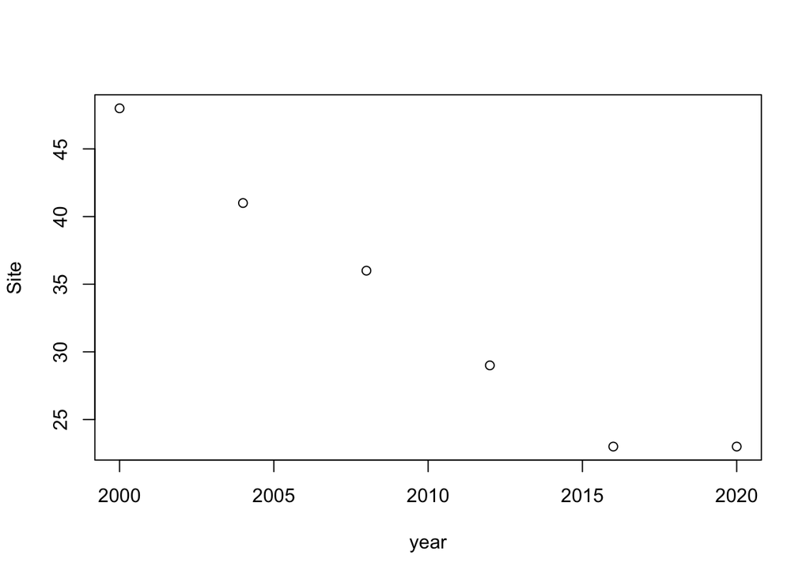

```r
# Produce a scatter plot to check relationship between year and site D .
plot(historical$Year, historical$Site_D, xlab="year",ylab="Site")
```

The relationship looks approximately linear. We can fit the linear model using the `lm` command.

```r
 # Using the lm function to fit a linear model
breeding_pairs <- c(historical$Site_D)
year <- c(historical$Year)
model=lm(breeding_pairs~year)
# Display the estimated coefficients
model
```

```
##
## Call:
## lm(formula = breeding_pairs ~ year)
##
## Coefficients:
## (Intercept)         year
##    2703.762       -1.329
```

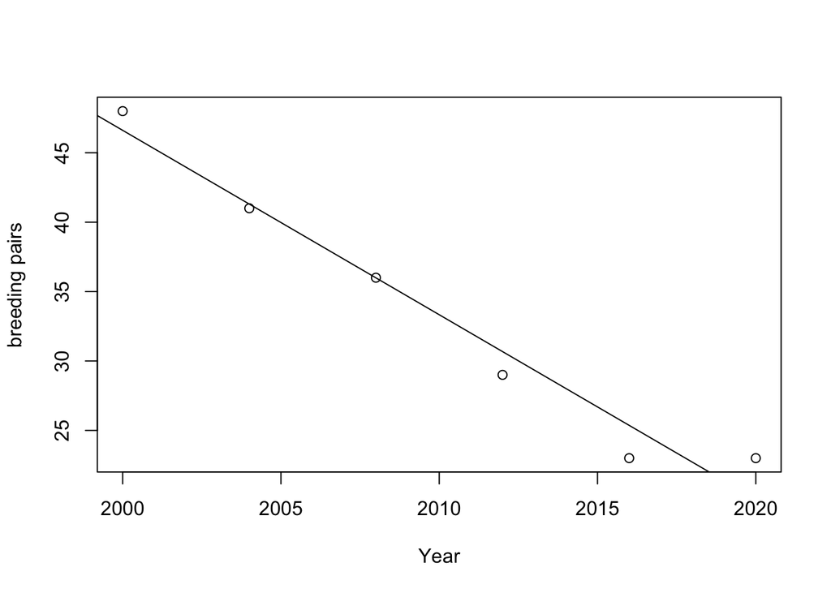

```r
# plotting the fitted model
plot(year, breeding_pairs, xlab="Year",ylab="breeding pairs") # Produce a scatter plot
abline(a=model$coef[1],b=model$coef[2])# Overlay the fitted line with intercept a and slope b
```

Now let’s check the model assumptions. We can observe linearity above so Now we check normality and homogeneity.

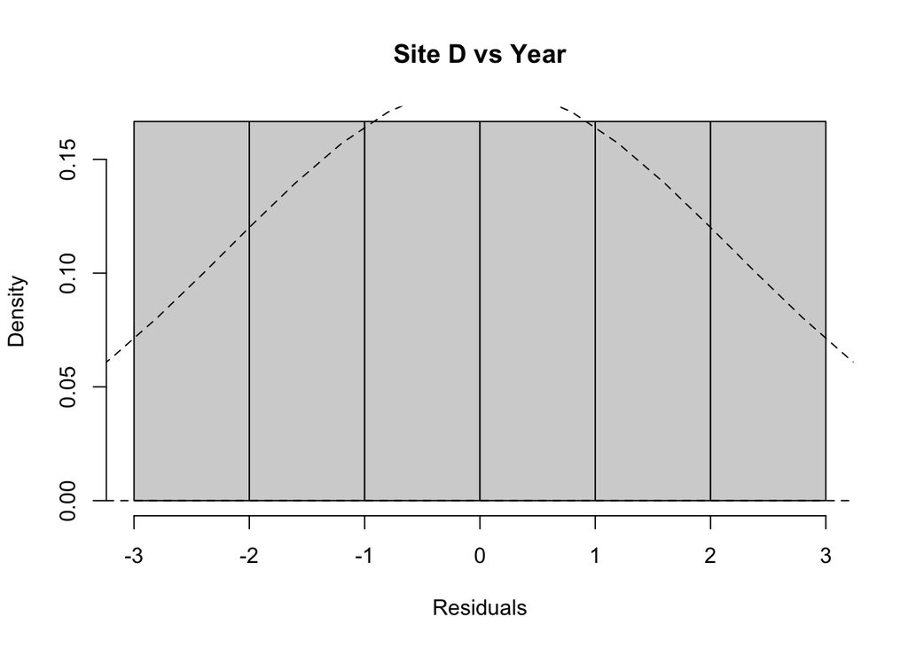

```r
# histogram of residuals
hist(model$residuals, main="Site D vs Year", xlab="Residuals",freq=FALSE)

# Overlay normal density curve, with sd of residuals, (-20,20) is the range to consider, lty=2 makes it a dashed line, and add=TRUE adds the line to the previous plot.
curve(dnorm(x,0,summary(model)$sigma),-20, 20,lty=2,add=TRUE)

# Plot the residuals against fitted values.
abline(h=0,lty=2) # add a horizontal dashed line at 0
```

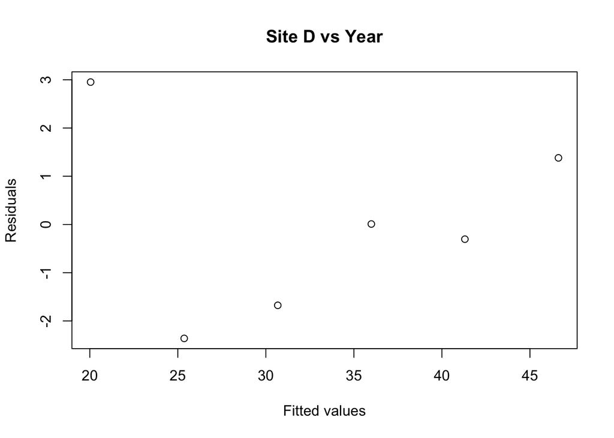

```r
plot(model$fitted.values, model$residuals, xlab="Fitted values",ylab="Residuals", main="Site D vs Year")
```

we can see the model is not normal from the Histogram plot of residuals. and we observe the residuals have consistent variance across different levels of the predictors.

```r
newdata<- data.frame(year = 2009)
 # A vector of hypothetical values at which to predict year

pred<-predict(model,newdata = newdata , interval="prediction") # Use the predict function to calculate the predictions
pred # Observe the predictions and prediction intervals
```

```
##       fit      lwr      upr
## 1 34.6619 28.09793 41.22588
```

```r
summary(model)
```

```
##
## Call:
## lm(formula = breeding_pairs ~ year)
##
## Residuals:
##         1         2         3         4         5         6
##  1.380952 -0.304762  0.009524 -1.676190 -2.361905  2.952381
##
## Coefficients:
##              Estimate Std. Error t value Pr(>|t|)
## (Intercept) 2703.7619   262.5188   10.30 0.000501 ***
## year          -1.3286     0.1306  -10.17 0.000526 ***
## ---
## Signif. codes:  0 '***' 0.001 '**' 0.01 '*' 0.05 '.' 0.1 ' ' 1
##
## Residual standard error: 2.185 on 4 degrees of freedom
## Multiple R-squared:  0.9628, Adjusted R-squared:  0.9535
## F-statistic: 103.5 on 1 and 4 DF,  p-value: 0.000526
```

# Question 3.

#Question 3a. Creating a visual summary of the measurement data.

```r
data3 <-read.csv("Kittiwake_Measurement_20603681.csv")
head(data3)
```

```
##    Sub.species Weight Wingspan Culmen
## 1   Red-legged    360      102     26
## 2 Black-legged    358      115     40
## 3   Red-legged    349      108     37
## 4 Black-legged    387      126     39
## 5 Black-legged    374      111     35
## 6 Black-legged    357      110     39
```

```r
black_leg <- subset(data3, Sub.species =="Black-legged")
red_leg <- subset(data3, Sub.species == "Red-legged")

black_leg
```

```
##     Sub.species Weight Wingspan Culmen
## 2  Black-legged    358      115     40
## 4  Black-legged    387      126     39
## 5  Black-legged    374      111     35
## 6  Black-legged    357      110     39
## 10 Black-legged    357      118     40
## 14 Black-legged    352      103     39
## 15 Black-legged    356      115     41
## 16 Black-legged    341       94     39
## 17 Black-legged    349      100     37
## 19 Black-legged    347       97     36
## 21 Black-legged    365      108     36
## 22 Black-legged    366      110     38
## 24 Black-legged    357      112     40
## 26 Black-legged    377      128     40
## 27 Black-legged    352      106     40
## 28 Black-legged    363      109     35
```

```r
red_leg
```

```
##    Sub.species Weight Wingspan Culmen
## 1   Red-legged    360      102     26
## 3   Red-legged    349      108     37
## 7   Red-legged    366      114     26
## 8   Red-legged    361      111     26
## 9   Red-legged    362       98     34
## 11  Red-legged    367      119     37
## 12  Red-legged    344      107     36
## 13  Red-legged    356       99     29
## 18  Red-legged    367      110     34
## 20  Red-legged    331       99     27
## 23  Red-legged    357      101     28
## 25  Red-legged    352      107     28
## 29  Red-legged    345       99     28
## 30  Red-legged    355      102     30
```

```r
black_leg <- black_leg[, c("Weight", "Wingspan", "Culmen")]
red_leg <- red_leg[, c("Weight", "Wingspan", "Culmen")]
black_leg
```

```
##    Weight Wingspan Culmen
## 2     358      115     40
## 4     387      126     39
## 5     374      111     35
## 6     357      110     39
## 10    357      118     40
## 14    352      103     39
## 15    356      115     41
## 16    341       94     39
## 17    349      100     37
## 19    347       97     36
## 21    365      108     36
## 22    366      110     38
## 24    357      112     40
## 26    377      128     40
## 27    352      106     40
## 28    363      109     35
```

```r
red_leg
```

```
##    Weight Wingspan Culmen
## 1     360      102     26
## 3     349      108     37
## 7     366      114     26
## 8     361      111     26
## 9     362       98     34
## 11    367      119     37
## 12    344      107     36
## 13    356       99     29
## 18    367      110     34
## 20    331       99     27
## 23    357      101     28
## 25    352      107     28
## 29    345       99     28
## 30    355      102     30
```

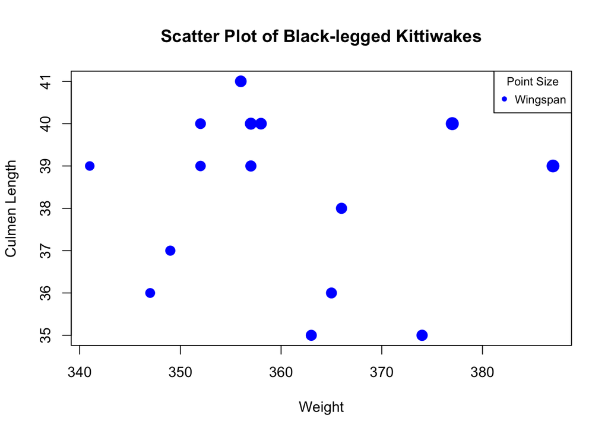

```r
#plotting a scatter plot for each table: black_leg of culmen against weight.

# Scatter plot
plot(black_leg$Weight, black_leg$Culmen,
     xlab = "Weight", ylab = "Culmen Length",
     main = "Scatter Plot of Black-legged Kittiwakes",
     pch = 16, col = "blue")

# Adding wingspan as a third dimension using point size
points(black_leg$Weight, black_leg$Culmen,
       cex = black_leg$Wingspan / max(black_leg$Wingspan) * 2,
       pch = 16, col = "blue")

# Adding a legend for the point size
legend("topright", legend = "Wingspan",
       pch = 16, col = "blue",
       title = "Point Size", cex = 0.8)
```

```r
# Display the plot
dev.new()
```

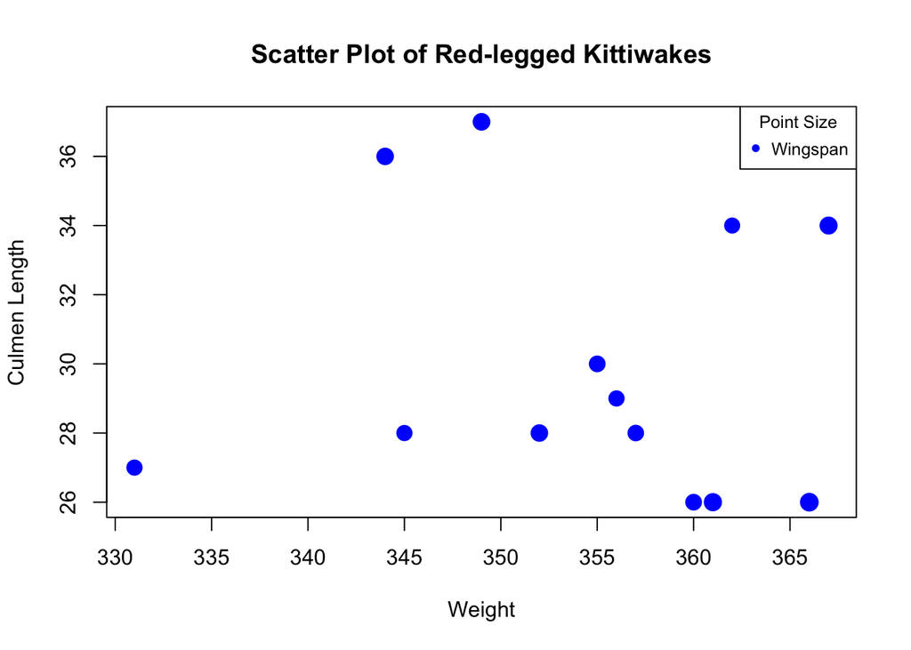

```r
#plotting a scatter plot for each table: red_leg of culmen against weight.

# Scatter plot
plot(red_leg$Weight, red_leg$Culmen, xlab = "Weight", ylab = "Culmen Length", main = "Scatter Plot of Red-legged Kittiwakes",pch = 16, col = "blue")

# Adding wingspan as a third dimension using point size
points(red_leg$Weight, red_leg$Culmen, cex = red_leg$Wingspan / max(red_leg$Wingspan) * 2, pch = 16, col = "blue")

# Adding a legend for the point size
legend("topright", legend = "Wingspan", pch = 16, col = "blue", title = "Point Size", cex = 0.8)
```

```r
# Display the plot
dev.new()
```

Scatter plot of culmen against weight and the wingspan as a point size does not depict much relationship between the weight, culmen length and wingspan.

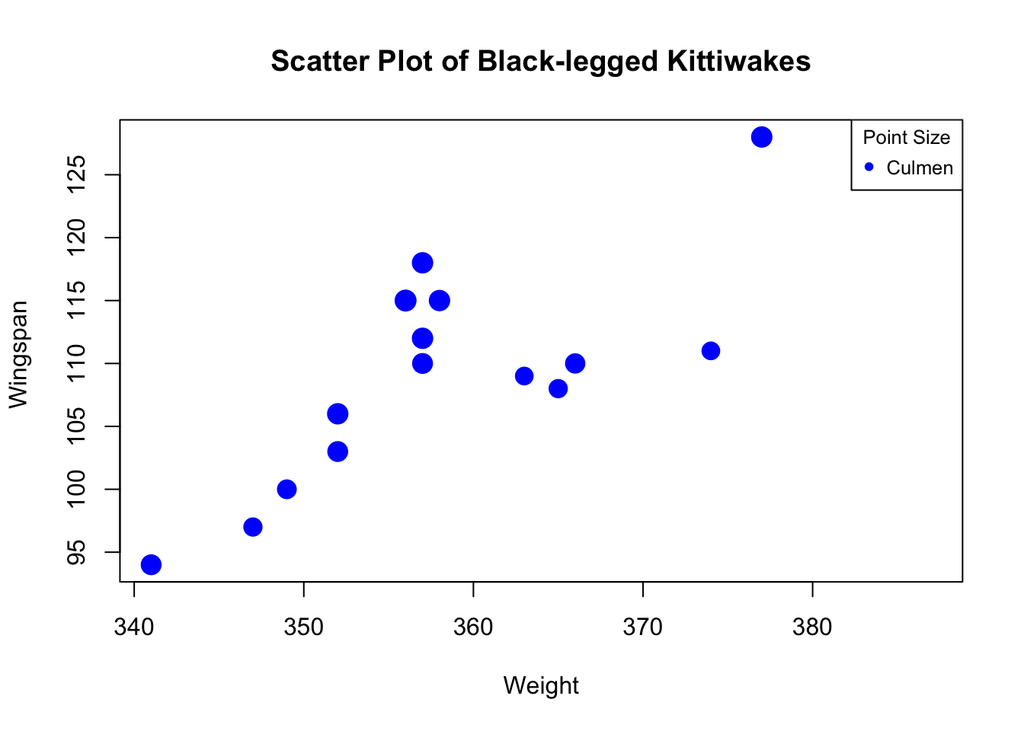

```r
#plotting a scatter plot for each table: black_leg of Wingspan against weight culmen as a third dimension using point size

# Scatter plot
plot(black_leg$Weight, black_leg$Wingspan,
     xlab = "Weight", ylab = "Wingspan ",
     main = "Scatter Plot of Black-legged Kittiwakes",
     pch = 16, col = "blue")

# Adding culmen as a third dimension using point size
points(black_leg$Weight, black_leg$Wingspan,
       cex = black_leg$Culmen / max(black_leg$Culmen) * 2,
       pch = 16, col = "blue")

# Adding a legend for the point size
legend("topright", legend = "Culmen",
       pch = 16, col = "blue",
       title = "Point Size", cex = 0.8)
```

```r
# Display the plot
dev.new()
```

The scatter plot shows there is a relationship between the wingspan and the weight as against the plot of culmen against weight

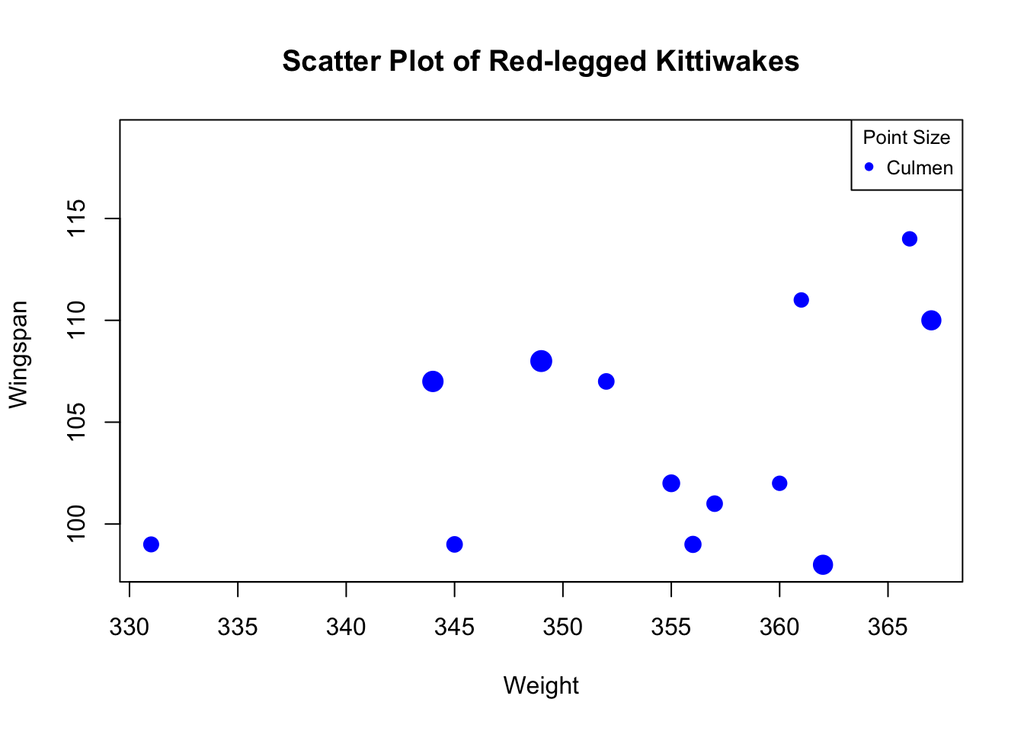

```r
#plotting a scatter plot for each table: red_leg of Wingspan against weight culmen as a third dimension using point size

# Scatter plot
plot(red_leg$Weight, red_leg$Wingspan, xlab = "Weight", ylab = "Wingspan ", main = "Scatter Plot of Red-legged Kittiwakes",pch = 16, col = "blue")

# Adding culmen as a third dimension using point size
points(red_leg$Weight, red_leg$Wingspan, cex = red_leg$Culmen / max(red_leg$Culmen) * 2, pch = 16, col = "blue")

# Adding a legend for the point size
legend("topright", legend = "Culmen", pch = 16, col = "blue", title = "Point Size", cex = 0.8)
```

```r
# Display the plot
dev.new()
```

```r
summary(black_leg)
```

```
##      Weight         Wingspan         Culmen
##  Min.   :341.0   Min.   : 94.0   Min.   :35.00
##  1st Qu.:352.0   1st Qu.:105.2   1st Qu.:36.75
##  Median :357.0   Median :110.0   Median :39.00
##  Mean   :359.9   Mean   :110.1   Mean   :38.38
##  3rd Qu.:365.2   3rd Qu.:115.0   3rd Qu.:40.00
##  Max.   :387.0   Max.   :128.0   Max.   :41.00
```

```r
summary(red_leg)
```

```
##      Weight         Wingspan         Culmen
##  Min.   :331.0   Min.   : 98.0   Min.   :26.00
##  1st Qu.:349.8   1st Qu.: 99.5   1st Qu.:27.25
##  Median :356.5   Median :104.5   Median :28.50
##  Mean   :355.1   Mean   :105.4   Mean   :30.43
##  3rd Qu.:361.8   3rd Qu.:109.5   3rd Qu.:34.00
##  Max.   :367.0   Max.   :119.0   Max.   :37.00
```

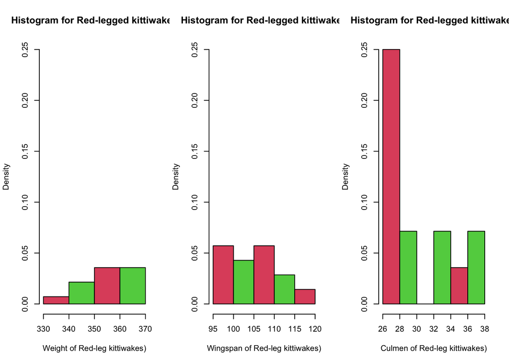

```r
par(mfrow=c(1,3))
hist(red_leg$Weight, xlab= "Weight of Red-leg kittiwakes)",freq=FALSE, ylim=c(0,0.25), col=c(2,3), main= "Histogram for Red-legged kittiwakes" )
hist(red_leg$Wingspan, xlab= "Wingspan of Red-leg kittiwakes)",freq=FALSE, ylim=c(0,0.25), col=c(2,3), main= "Histogram for Red-legged kittiwakes" )
hist(red_leg$Culmen, xlab= "Culmen of Red-leg kittiwakes)",freq=FALSE, ylim=c(0,0.25), col=c(2,3), main= "Histogram for Red-legged kittiwakes" )
```

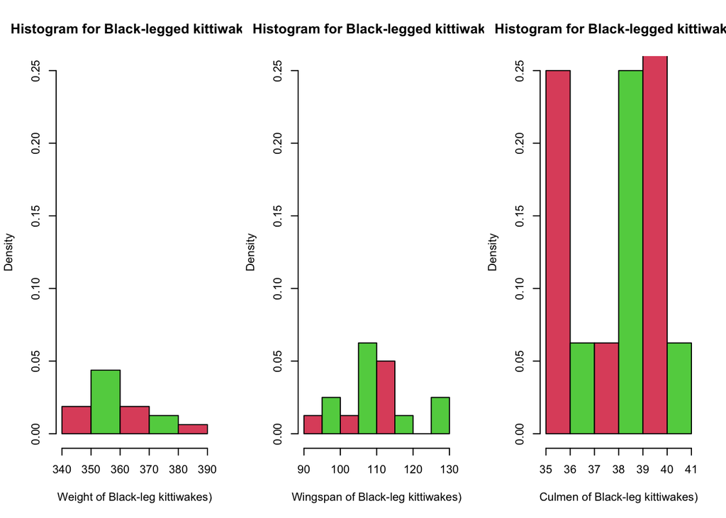

```r
hist(black_leg$Weight, xlab= "Weight of Black-leg kittiwakes)",freq=FALSE, ylim=c(0,0.25), col=c(2,3), main= "Histogram for Black-legged kittiwakes" )
hist(black_leg$Wingspan, xlab= "Wingspan of Black-leg kittiwakes)",freq=FALSE, ylim=c(0,0.25), col=c(2,3), main= "Histogram for Black-legged kittiwakes" )
hist(black_leg$Culmen, xlab= "Culmen of Black-leg kittiwakes)",freq=FALSE, ylim=c(0,0.25), col=c(2,3), main= "Histogram for Black-legged kittiwakes" )
```

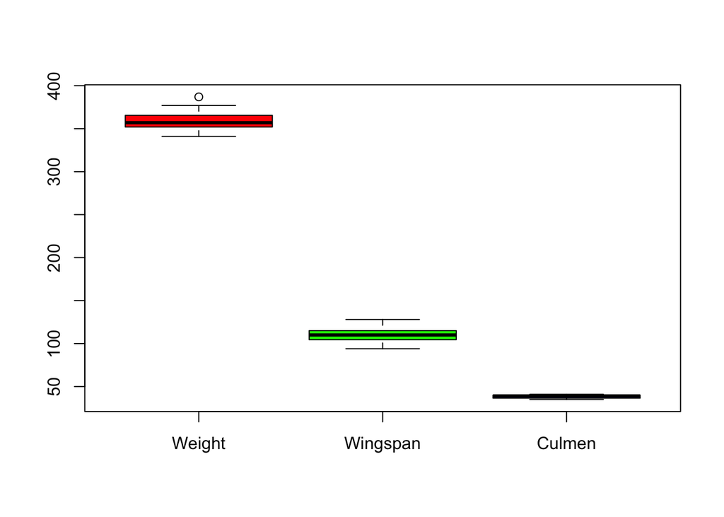

```r
#Plotting boxplot for black-leg and red-leg kittiwakes
boxplot(black_leg, col = rainbow(ncol(trees)))
```

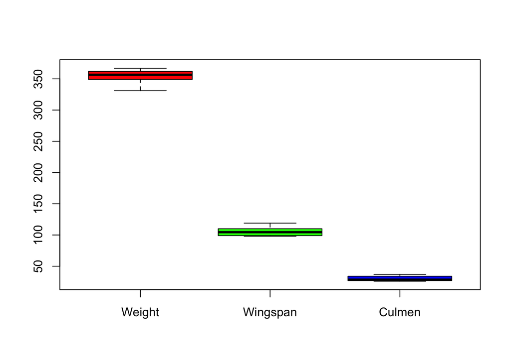

```r
boxplot(red_leg, col = rainbow(ncol(trees)))
```

The joint boxplot does not give a good visual summary rather an individual summary.

Trying the seperate box plot.

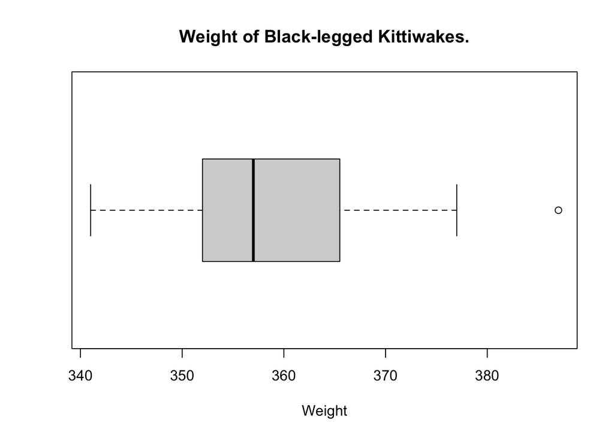

```r
#Boxplot of Weight, Wingspan and Culmen of Black-legged Kittwakes.
boxplot(black_leg$Weight , horizontal=TRUE, xlab= "Weight", main= "Weight of Black-legged Kittiwakes." )
```

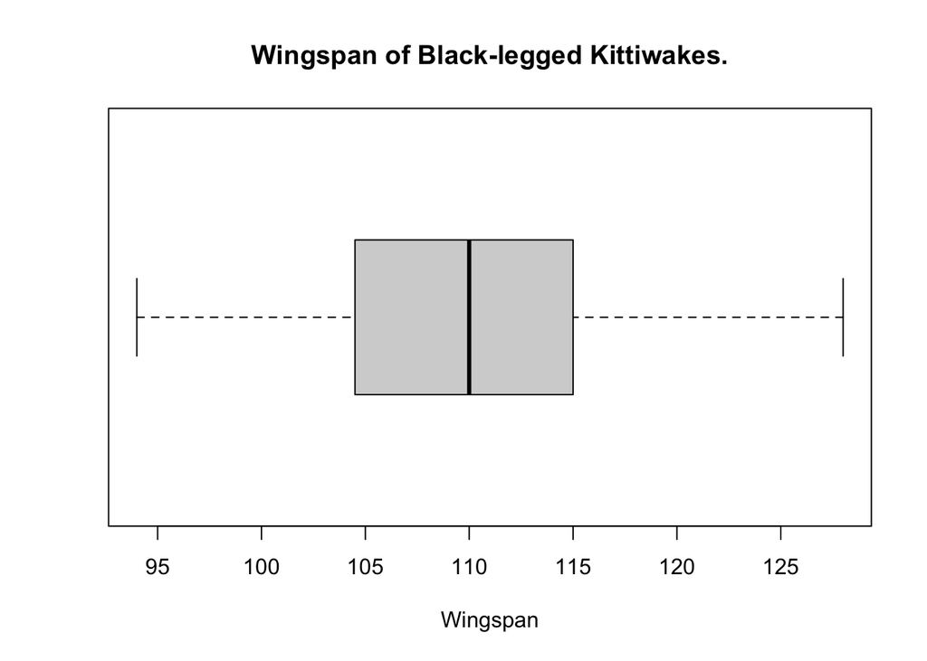

```r
boxplot(black_leg$Wingspan , horizontal=TRUE, xlab= "Wingspan", main= "Wingspan of Black-legged Kittiwakes." )
```

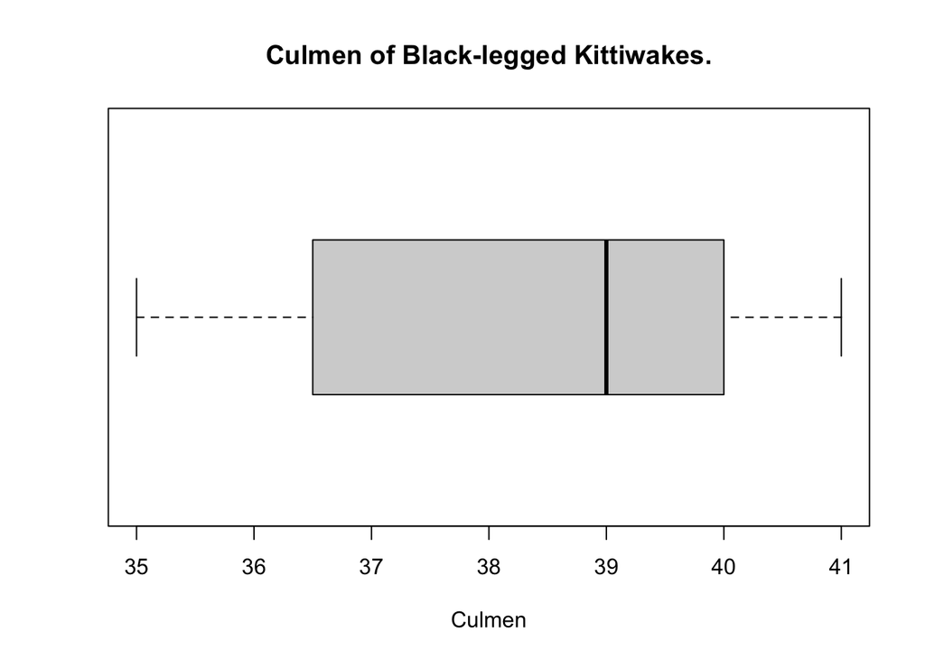

```r
boxplot(black_leg$Culmen , horizontal=TRUE, xlab= "Culmen", main= "Culmen of Black-legged Kittiwakes." )
```

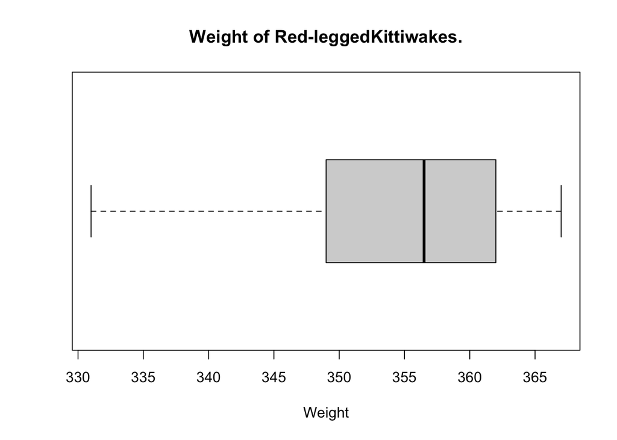

```r
#Boxplot of Weight, Wingspan and Culmen of Red-legged Kittwakes.
boxplot(red_leg$Weight , horizontal=TRUE, xlab= "Weight", main= "Weight of Red-leggedKittiwakes." )
```

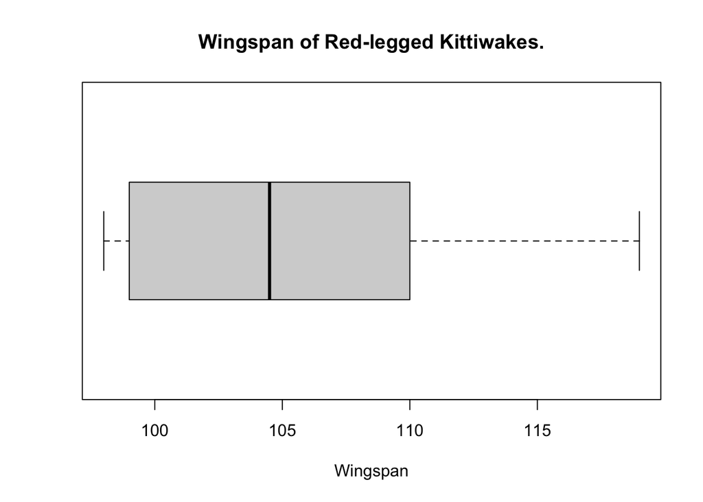

```r
boxplot(red_leg$Wingspan , horizontal=TRUE, xlab= "Wingspan", main= "Wingspan of Red-legged Kittiwakes." )
```

[figure not shown]

[output not shown]

[output not shown]

```r
boxplot(red_leg$Culmen , horizontal=TRUE, xlab= "Culmen", main= "Culmen of Red-legged Kittiwakes." )
```

```r
round(mean(red_leg$Culmen), 3)
```

```
## [1] 30.429
```

```r
round(sd(red_leg$Wingspan), 3)
```

```
## [1] 6.465
```

```r
round(sd(red_leg$Culmen), 3)
```

```
## [1] 4.237
```

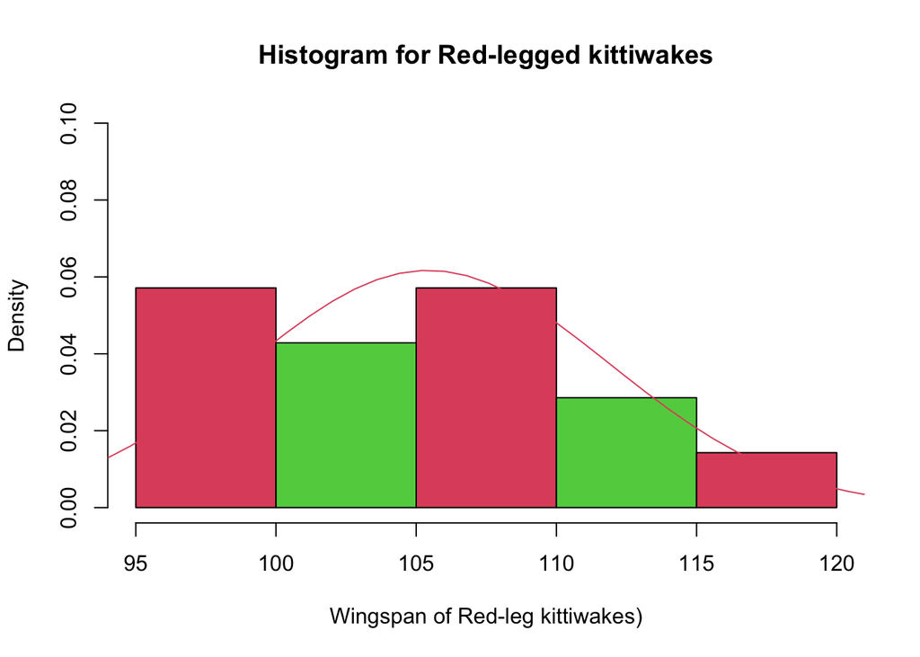

```r
#check for normality for red legged specie inputing the mean and sd

hist(red_leg$Wingspan, xlab= "Wingspan of Red-leg kittiwakes)",freq=FALSE, ylim=c(0,0.1), col=c(2,3), main= "Histogram for Red-legged kittiwakes" )
curve(dnorm(x, 105.429, 6.465), 50, 130,, col=2,add=TRUE)
```

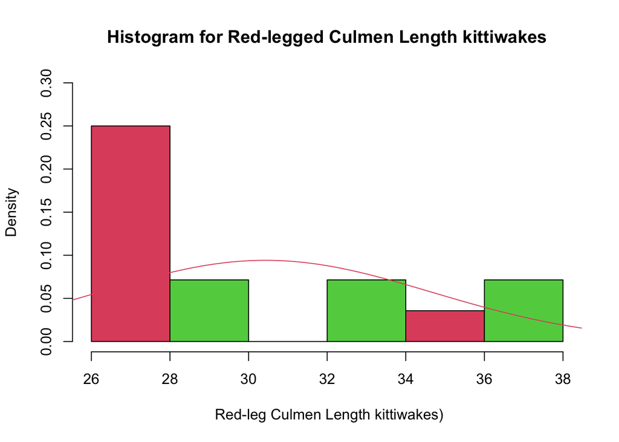

```r
hist(red_leg$Culmen, xlab= " Red-leg Culmen Length kittiwakes)",freq=FALSE, ylim=c(0,0.3), col=c(2,3), main= "Histogram for Red-legged Culmen Length kittiwakes" )
curve(dnorm(x, 30.429, 4.237),  20, 40, col=2, add=TRUE)
```

for the red-legged specie, we can see that it is not a normal distribution, the culmen length is skewed to the right (positive skewness) while the Wingspan is skewed to the right too(positive skewness) and earlier we see there is no linear correlation between the culmen length and weight of the red-legged specie. therefor we perform a correlation test finally to check for independence.

```r
cor.test(red_leg$Wingspan,red_leg$Culmen)
```

```
##
##  Pearson's product-moment correlation
##
## data:  red_leg$Wingspan and red_leg$Culmen
## t = 1.1524, df = 12, p-value = 0.2716
## alternative hypothesis: true correlation is not equal to 0
## 95 percent confidence interval:
##  -0.2581495  0.7248445
## sample estimates:
##       cor
## 0.3156665
```

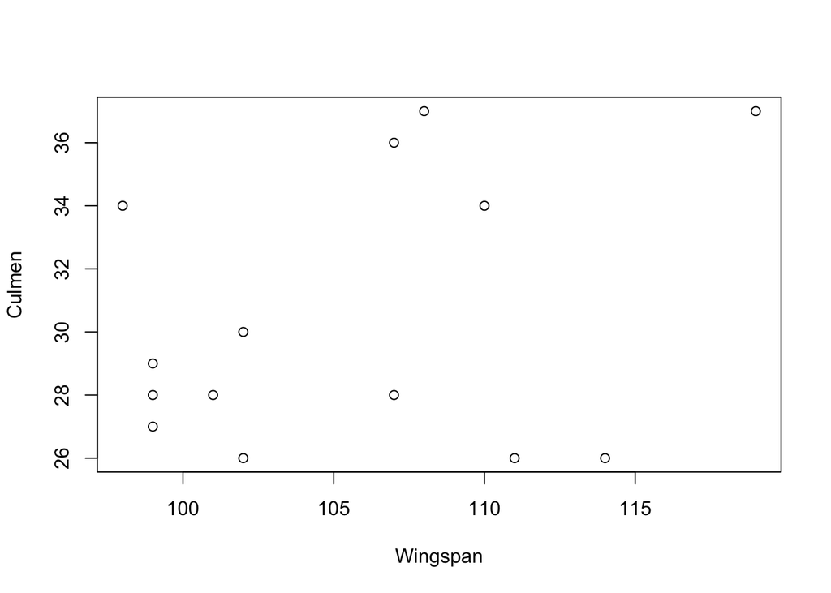

```r
plot(red_leg$Wingspan, red_leg$Culmen, xlab="Wingspan",ylab="Culmen")
```

```r
r <-0.3156
n <- length(red_leg$Wingspan)
n
```

```
## [1] 14
```

```r
t <- r*(sqrt((n-2)/(1-r^2)))
t
```

```
## [1] 1.152154
```

```r
critical_value_red <- qt(0.995,12)
critical_value_red
```

```
## [1] 3.05454
```

Black legged

```r
#getting mean and sd for weight and culment lenght  black leg species
round(mean(black_leg$Wingspan), 3)
```

```
## [1] 110.125
```

```r
round(mean(black_leg$Culmen), 3)
```

```
## [1] 38.375
```

```r
round(sd(black_leg$Wingspan), 3)
```

```
## [1] 9.287
```

```r
round(sd(black_leg$Culmen), 3)
```

```
## [1] 1.962
```

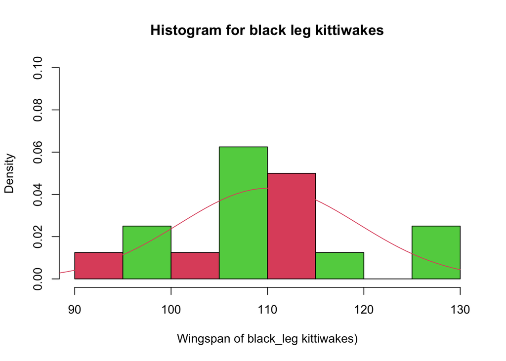

```r
#check for normality for black legged specie inputing the mean and sd

hist(black_leg$Wingspan, xlab= "Wingspan of black_leg kittiwakes)",freq=FALSE, ylim=c(0,0.1), col=c(2,3), main= "Histogram for black leg kittiwakes" )
curve(dnorm(x, 110.125, 9.287),  50, 130, col=2,add=TRUE)
```

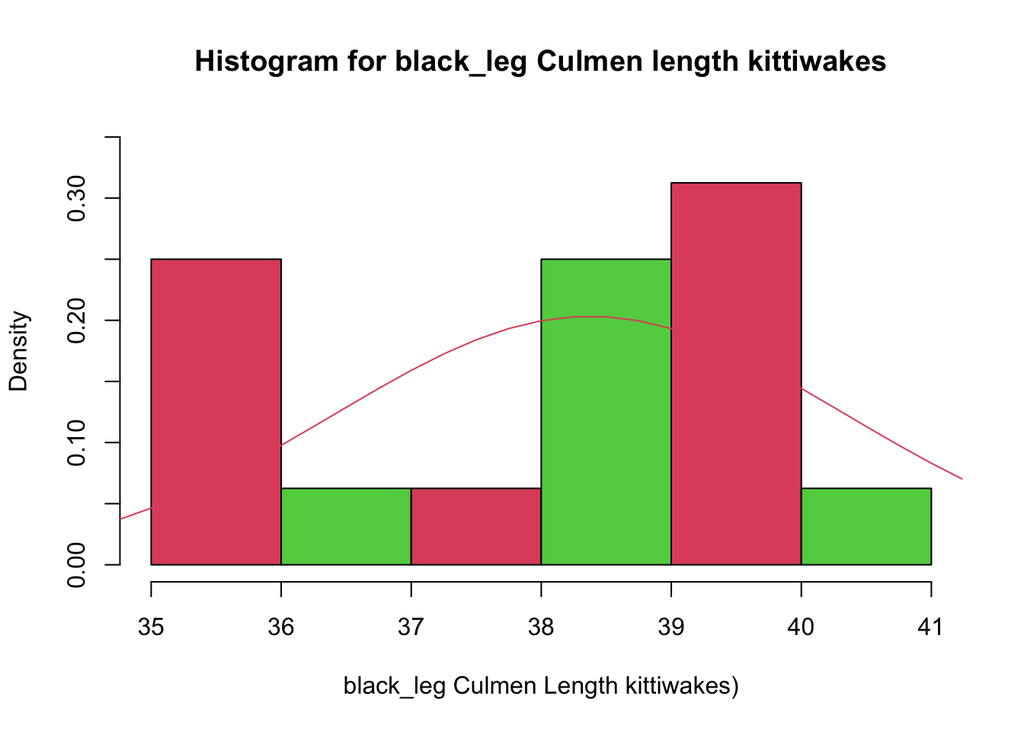

```r
hist(black_leg$Culmen, xlab= "black_leg Culmen Length kittiwakes)",freq=FALSE, ylim=c(0,0.35), col=c(2,3), main= "Histogram for black_leg Culmen length kittiwakes" )
curve(dnorm(x, 38.375, 1.962), 20, 45, col=2,add=TRUE)
```

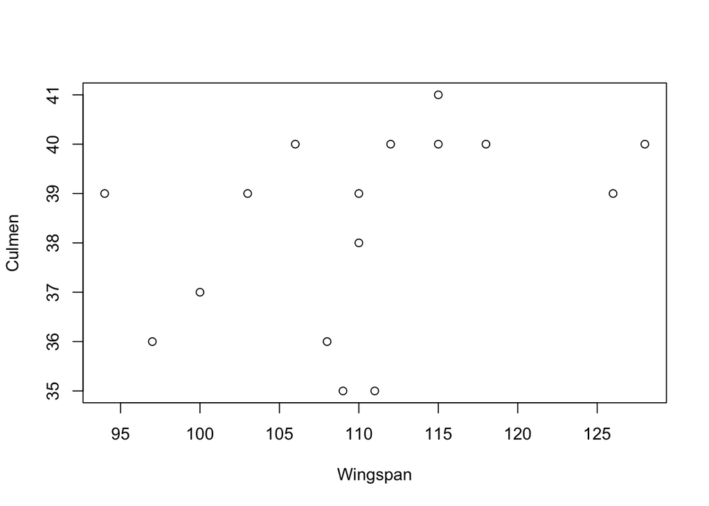

```r
plot(black_leg$Wingspan, black_leg$Culmen, xlab="Wingspan",ylab="Culmen")
```

```r
cor.test(black_leg$Wingspan, black_leg$Culmen)
```

```
##
##  Pearson's product-moment correlation
##
## data:  black_leg$Wingspan and black_leg$Culmen
## t = 1.5611, df = 14, p-value = 0.1408
## alternative hypothesis: true correlation is not equal to 0
## 95 percent confidence interval:
##  -0.1367548  0.7395908
## sample estimates:
##       cor
## 0.3850534
```

```r
#correlation coefficient
r <-0.3851
n <- length(black_leg$Wingspan)
n
```

```
## [1] 16
```

```r
t <- r*(sqrt((n-2)/(1-r^2)))
t
```

```
## [1] 1.56133
```

```r
#
critical_value_black <- qt(0.995,14)
critical_value_black
```

```
## [1] 2.976843
```

# Question 3c.

3. Is there evidence that the weights of birds of the two sub-species are different? using the t-test statisitc to get the variance and the t value.

```r
var.test(red_leg$Weight, black_leg$Weight)
```

```
##
##  F test to compare two variances
##
## data:  red_leg$Weight and black_leg$Weight
## F = 0.74692, num df = 13, denom df = 15, p-value = 0.6036
## alternative hypothesis: true ratio of variances is not equal to 1
## 95 percent confidence interval:
##  0.2553672 2.2801466
## sample estimates:
## ratio of variances
##          0.7469246
```

```r
t.test(red_leg$Weight, black_leg$Weight,var.equal=TRUE )
```

```
##
##  Two Sample t-test
##
## data:  red_leg$Weight and black_leg$Weight
## t = -1.1606, df = 28, p-value = 0.2556
## alternative hypothesis: true difference in means is not equal to 0
## 95 percent confidence interval:
##  -13.083947   3.619661
## sample estimates:
## mean of x mean of y
##  355.1429  359.8750
```

```r
critical_t_value<-qt(0.975, df=16+14-2)
critical_t_value
```

```
## [1] 2.048407
```

# Question 3d hypothesis testing: • If the wingspan of black-legged and red-legged kittiwakes are different. • If culmen length of black-legged and red-legged kittiwakes are different. • If the weights of black-legged and red-legged are different.

```r
#If the wingspan of black-legged and red-legged kittiwakes are different.
t.test(black_leg$Wingspan, red_leg$Wingspan, var.equal = TRUE)
```

```
##
##  Two Sample t-test
##
## data:  black_leg$Wingspan and red_leg$Wingspan
## t = 1.5843, df = 28, p-value = 0.1244
## alternative hypothesis: true difference in means is not equal to 0
## 95 percent confidence interval:
##  -1.37582 10.76868
## sample estimates:
## mean of x mean of y
##  110.1250  105.4286
```

```r
#If culmen length of black-legged and red-legged kittiwakes are different
t.test(black_leg$Culmen, red_leg$Culmen, var.equal = TRUE)
```

```
##
##  Two Sample t-test
##
## data:  black_leg$Culmen and red_leg$Culmen
## t = 6.7334, df = 28, p-value = 2.606e-07
## alternative hypothesis: true difference in means is not equal to 0
## 95 percent confidence interval:
##   5.52900 10.36386
## sample estimates:
## mean of x mean of y
##  38.37500  30.42857
```

```r
#If the weights of black-legged and red-legged are different.
t.test(red_leg$Weight, black_leg$Weight,var.equal=TRUE )
```

```
##
##  Two Sample t-test
##
## data:  red_leg$Weight and black_leg$Weight
## t = -1.1606, df = 28, p-value = 0.2556
## alternative hypothesis: true difference in means is not equal to 0
## 95 percent confidence interval:
##  -13.083947   3.619661
## sample estimates:
## mean of x mean of y
##  355.1429  359.8750
```

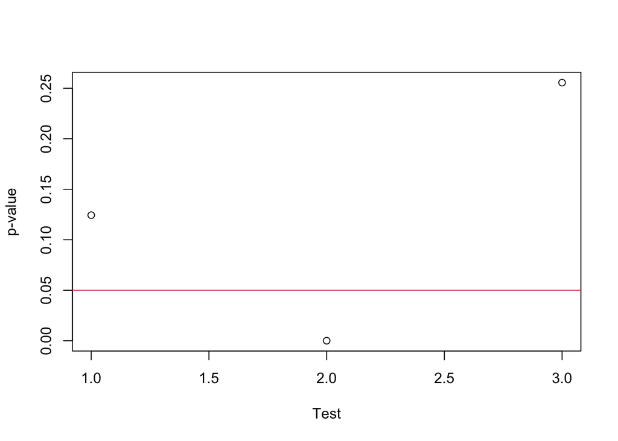

```r
pvalues<-rep(NA,3) # create a blank vector to store p values
pvalues[1]<-t.test(black_leg$Wingspan, red_leg$Wingspan, var.equal = TRUE)$p.value
pvalues[2]<-t.test(black_leg$Culmen, red_leg$Culmen, var.equal = TRUE)$p.value
pvalues[3]<-t.test(red_leg$Weight, black_leg$Weight,var.equal=TRUE )$p.value

plot(pvalues,xlab="Test",ylab="p-value") # plot the p values
abline(h=0.05,col=2) # add horizontal line at 0.05, coloured red
```

This result shows only 1 test is significant which is test 2 for black_leg Culmen length and red_leg Culmen length. Using the Bonferonni correction:

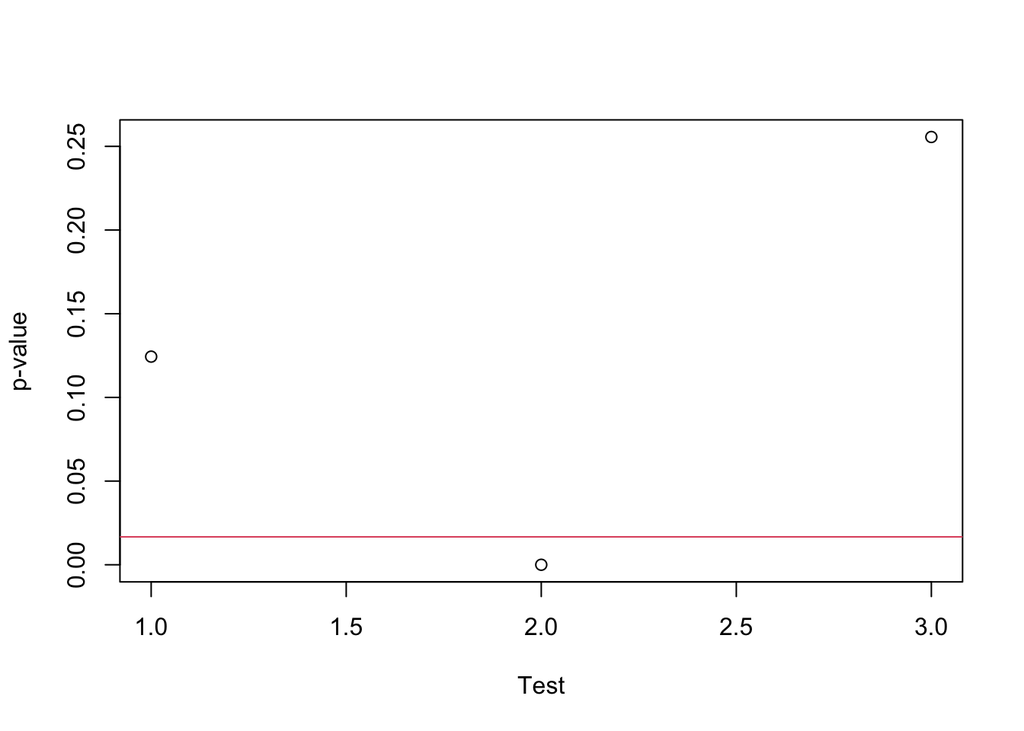

```r
m<-length(pvalues) # number of tests
plot(pvalues,xlab="Test",ylab="p-value") # plot the p values
abline(h=0.05/m,col=2) # add horizontal line at 0.05/m
```

Now the Benjamin Hochberg procedure gives:

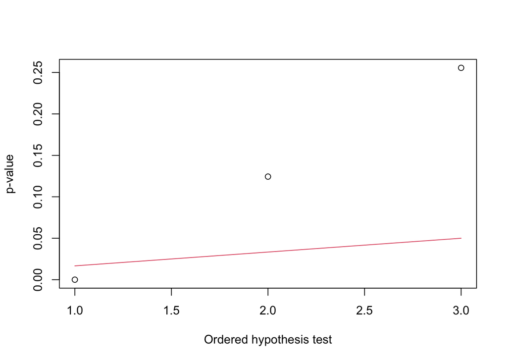

```r
plot(sort(pvalues),xlab="Ordered hypothesis test",ylab="p-value") # plot the p values in order from smallest to biggest
lines(1:m,0.05*(1:m)/m,col=2) # add a line showing 0.05*k/m for each value of k between 1 and m.
```

So this suggests the tests with the smallest $p$-values are signficant after all and only one siginficant test.

# Question 4.

```r
location <- read.csv("Kittiwake_Location_20603681.csv")
head(location)
```

```
##   Coast.direction sandeel Summer.temp cliff.height Breeding.pairs
## 1            West    1.12        17.4         3.65             62
## 2           South    2.65        20.7         3.73            108
## 3           North    1.27        14.0         3.43             29
## 4            West    2.64        19.7         3.30             68
## 5            West    1.82        16.7         4.36            159
## 6           North    2.56        18.3         3.93             84
```

```r
dim(location)
```

```
## [1] 33  5
```

For the Location data the ornithologist asks you to: a) Fit a linear model to predict the number of breeding pairs

# Question 4a-c

Firstly, we fit a linear model to the data using all the covariates.

```r
model1=lm(Breeding.pairs~.,data=location)
summary(model1)
```

```
##
## Call:
## lm(formula = Breeding.pairs ~ ., data = location)
##
## Residuals:
##      Min       1Q   Median       3Q      Max
## -100.796  -24.912   -0.589   17.060  174.843
##
## Coefficients:
##                       Estimate Std. Error t value Pr(>|t|)
## (Intercept)          -306.8623   131.3395  -2.336 0.027450 *
## Coast.directionNorth -220.1273    28.5327  -7.715 3.47e-08 ***
## Coast.directionSouth -182.7580    28.0146  -6.524 6.47e-07 ***
## Coast.directionWest  -202.8365    26.4045  -7.682 3.75e-08 ***
## sandeel                45.0393    11.8348   3.806 0.000775 ***
## Summer.temp             0.3595     3.6879   0.097 0.923100
## cliff.height          133.8136    22.1973   6.028 2.29e-06 ***
## ---
## Signif. codes:  0 '***' 0.001 '**' 0.01 '*' 0.05 '.' 0.1 ' ' 1
##
## Residual standard error: 51.26 on 26 degrees of freedom
## Multiple R-squared:  0.8691, Adjusted R-squared:  0.8389
## F-statistic: 28.77 on 6 and 26 DF,  p-value: 2.689e-10
```

We note that for the categorical (coastal direction): East is taken to have coefficient 0 as the first category for coastal direction. the coefficient Coast.direction North is the expected difference in the number of breeding pairs of kittiwakes in the North as compared to the East.

The Summer Temperature has a high p-value, suggesting it is not important in the model. We can use the `step` function on `model1` (the full model) to test which covariates are important.

```r
AIC(model1)
```

```
## [1] 361.6125
```

check for fit of linear model for model1 Using the AIC function

```r
model1=lm(Breeding.pairs~.,data=location)
step(model1,step=1)
```

```
## Start:  AIC=265.96
## Breeding.pairs ~ Coast.direction + sandeel + Summer.temp + cliff.height
##
##                   Df Sum of Sq    RSS    AIC
## - Summer.temp      1        25  68330 263.98
## <none>                          68305 265.96
## - sandeel          1     38048 106353 278.57
## - cliff.height     1     95473 163778 292.82
## - Coast.direction  3    208814 277119 306.18
##
## Step:  AIC=263.97
## Breeding.pairs ~ Coast.direction + sandeel + cliff.height
```

```
##
## Call:
## lm(formula = Breeding.pairs ~ Coast.direction + sandeel + cliff.height,
##     data = location)
##
## Coefficients:
##          (Intercept)  Coast.directionNorth  Coast.directionSouth
##              -297.79               -221.23               -182.47
##  Coast.directionWest               sandeel          cliff.height
##              -202.96                 45.16                133.20
```

At the start the AIC is =265.96.

```r
model1<-lm(Breeding.pairs~.,data=location) # Fit a linear model with Breeding pairs  as the response variable and everything else as a covariate
step(model1,step=2) # Try removing each covariate in turn.  Stop after two covariates have been removed ("step=2")
```

```
## Start:  AIC=265.96
## Breeding.pairs ~ Coast.direction + sandeel + Summer.temp + cliff.height
##
##                   Df Sum of Sq    RSS    AIC
## - Summer.temp      1        25  68330 263.98
## <none>                          68305 265.96
## - sandeel          1     38048 106353 278.57
## - cliff.height     1     95473 163778 292.82
## - Coast.direction  3    208814 277119 306.18
##
## Step:  AIC=263.97
## Breeding.pairs ~ Coast.direction + sandeel + cliff.height
##
##                   Df Sum of Sq    RSS    AIC
## <none>                          68330 263.98
## - sandeel          1     38635 106965 276.76
## - cliff.height     1    102814 171143 292.27
## - Coast.direction  3    221128 289457 305.62
```

```
##
## Call:
## lm(formula = Breeding.pairs ~ Coast.direction + sandeel + cliff.height,
##     data = location)
##
## Coefficients:
##          (Intercept)  Coast.directionNorth  Coast.directionSouth
##              -297.79               -221.23               -182.47
##  Coast.directionWest               sandeel          cliff.height
##              -202.96                 45.16                133.20
```

After removing Summer temp. in the first step the AIC is 263.98. Removing Sandeel cause the AIC to increase to 276.76. We end the process.

```r
model1<-lm(Breeding.pairs~.,data=location) # Fit a linear model with Breeding pairs  as the response variable and everything else as a covariate
bestmodel1<-step(model1) # Try removing each covariate in turn.  Stop when no further reduction in AIC can be found
```

```
## Start:  AIC=265.96
## Breeding.pairs ~ Coast.direction + sandeel + Summer.temp + cliff.height
##
##                   Df Sum of Sq    RSS    AIC
## - Summer.temp      1        25  68330 263.98
## <none>                          68305 265.96
## - sandeel          1     38048 106353 278.57
## - cliff.height     1     95473 163778 292.82
## - Coast.direction  3    208814 277119 306.18
##
## Step:  AIC=263.97
## Breeding.pairs ~ Coast.direction + sandeel + cliff.height
##
##                   Df Sum of Sq    RSS    AIC
## <none>                          68330 263.98
## - sandeel          1     38635 106965 276.76
## - cliff.height     1    102814 171143 292.27
## - Coast.direction  3    221128 289457 305.62
```

```r
summary(bestmodel1) # Display a summary of the model with the lowest AIC
```

```
##
## Call:
## lm(formula = Breeding.pairs ~ Coast.direction + sandeel + cliff.height,
##     data = location)
##
## Residuals:
##     Min      1Q  Median      3Q     Max
## -99.804 -24.534   1.907  16.833 175.195
##
## Coefficients:
##                      Estimate Std. Error t value Pr(>|t|)
## (Intercept)           -297.79      90.97  -3.273 0.002910 **
## Coast.directionNorth  -221.23      25.73  -8.599 3.26e-09 ***
## Coast.directionSouth  -182.47      27.34  -6.674 3.66e-07 ***
## Coast.directionWest   -202.96      25.88  -7.841 1.97e-08 ***
## sandeel                 45.16      11.56   3.907 0.000565 ***
## cliff.height           133.20      20.90   6.374 7.95e-07 ***
## ---
## Signif. codes:  0 '***' 0.001 '**' 0.01 '*' 0.05 '.' 0.1 ' ' 1
##
## Residual standard error: 50.31 on 27 degrees of freedom
## Multiple R-squared:  0.869,  Adjusted R-squared:  0.8448
## F-statistic: 35.83 on 5 and 27 DF,  p-value: 4.23e-11
```

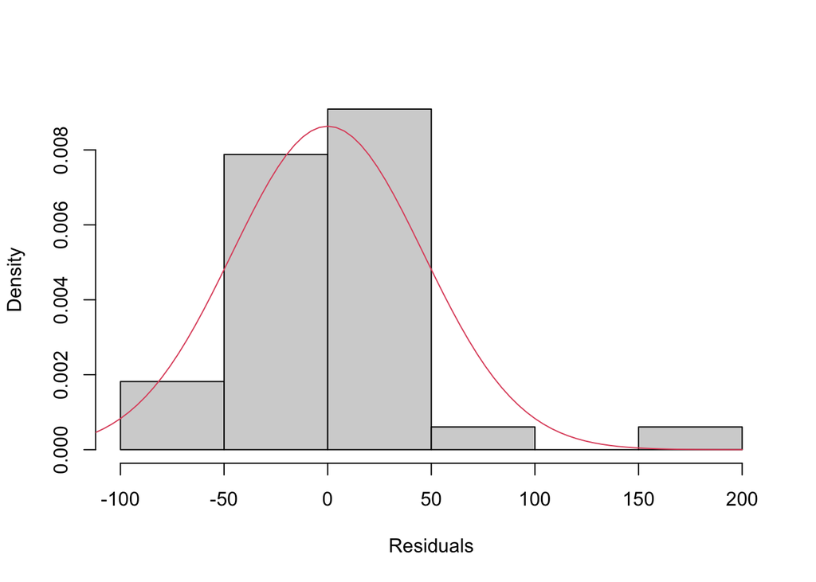

```r
hist(bestmodel1$residuals,xlab="Residuals",main="",freq=FALSE)
curve(dnorm(x,0,sd(bestmodel1$residuals)),-200,200,col=2,add=TRUE)
```